# DATA624_HW2

## Exercise 3

Why is a Box-Cox transformation unhelpful for the canadian_gas data?

```r
view(canadian_gas)
sum(is.na(canadian_gas))
```

```
## [1] 0
```

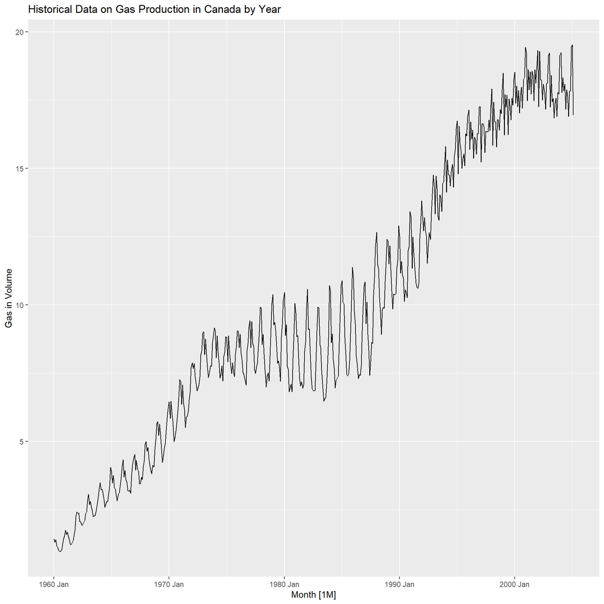

```r
cand1 <- canadian_gas %>%
        autoplot(Volume) + labs(title = "Historical Data on Gas Production in Canada by Year", y = "Gas in Volume" )
cand1
```

```r
print("Looking at this plot. it is hard to tell whether the box_cox () would have an effect due to the small variation in gas volume each year and max,min,quartile are not observed in one reference point. Let's recall what a box_cox () is: a box-cox transformation is a commonly used method for transforming a non-normally distributed dataset into a more normally distributed one.")
```

[output not shown]

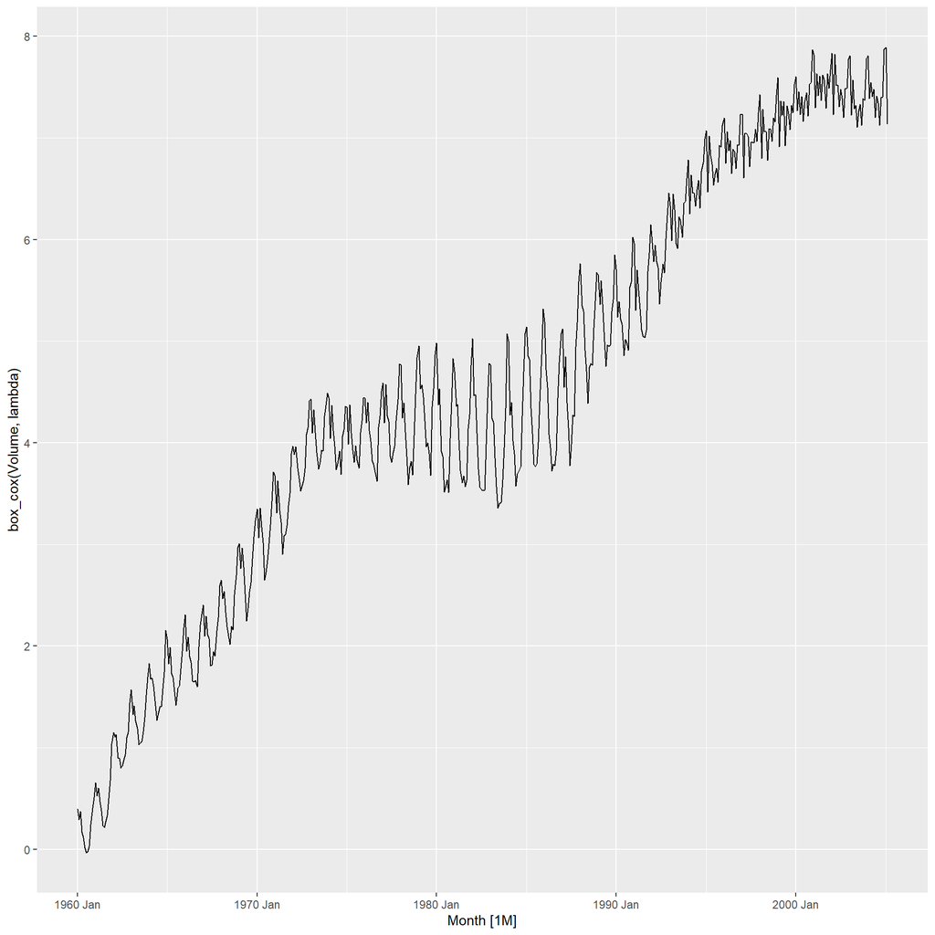

```r
#Let's find optimal lambda for Box-Cox transformation
# bc1 <- box_cox(Volume ~ Month)
# (lambda <- bc1$Month[which.max(bc1$Volume)])
#(lambda <- BoxCox.lambda(canadian_gas))
#fit <- snaive(canadian_gas, lambda=1/3)
#autoplot(BoxCox(canadian_gas, lambda))
# to find optimal lambda
#lambda = BoxCox.lambda( canadian_gas )
# now to transform vector
#trans.canadian_gas = BoxCox( canadian_gas, lambda)
lambda <- canadian_gas %>%
          features(Volume, features = guerrero)#%>%
          #box_cox(Volume)%>%
          canadian_gas %>%
          autoplot(box_cox(Volume, lambda))
```

```r
print("Not a significant change after applying box_cox, but parameter lambda has effect on normalizing the data")
```

```
## [1] "Not a significant change after applying box_cox, but parameter lambda has effect on normalizing the data"
```

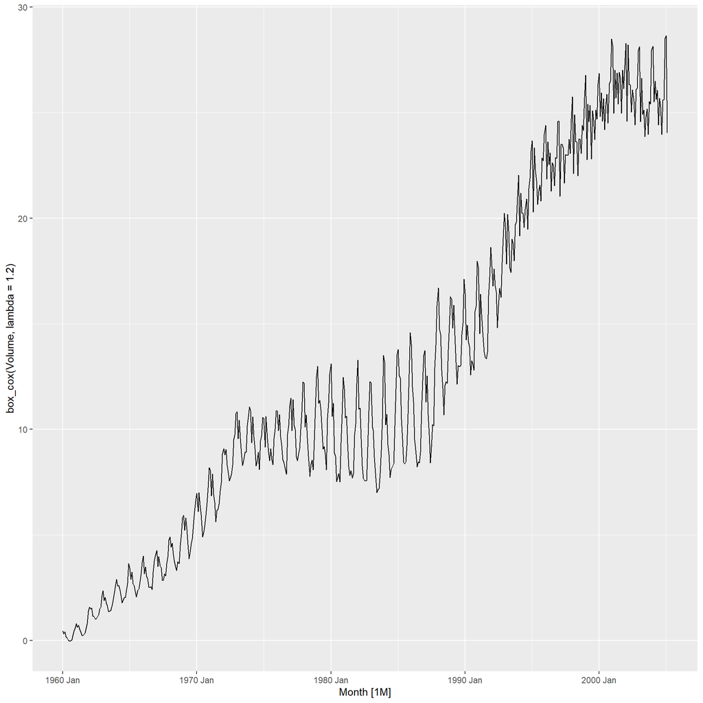

```r
          canadian_gas %>%
          autoplot(box_cox(Volume, lambda = 1.2))
```

```r
#qqnorm(model$residuals)
#qqline(model$residuals)
```

## Exercise 4

What Box-Cox transformation would you select for your retail data (from Exercise 8 in Section 2.10)?

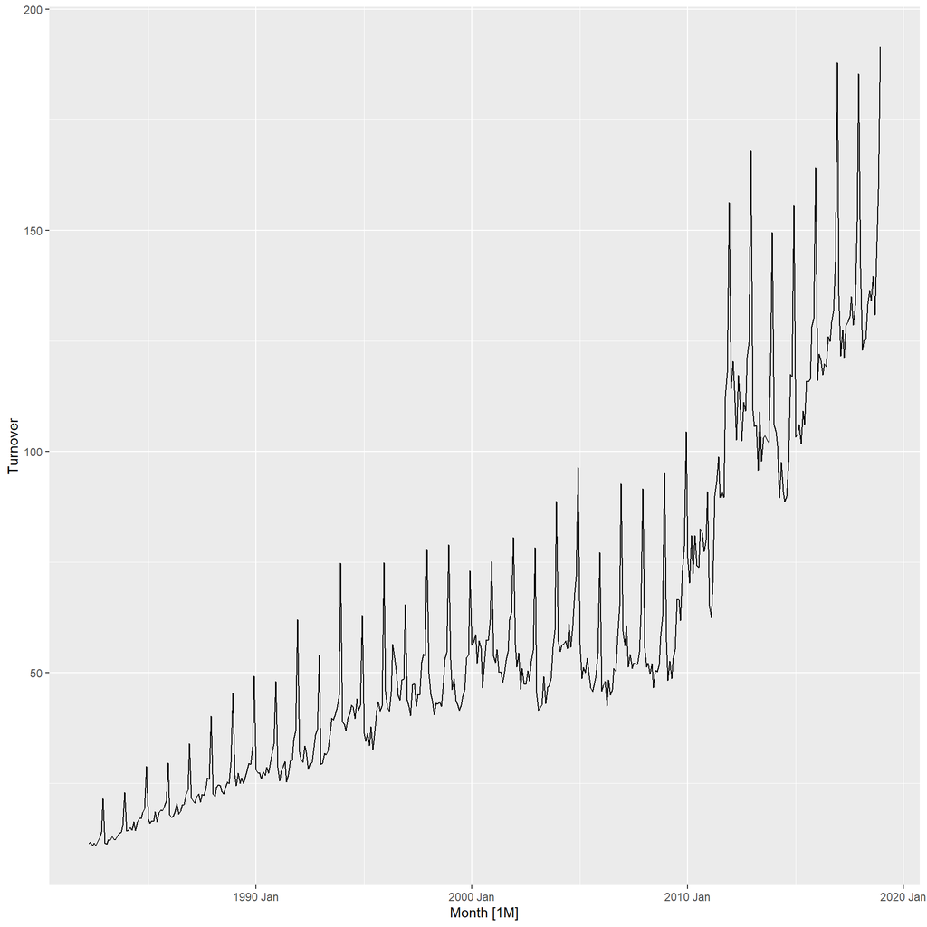

```r
set.seed(53566)
view(aus_retail)
myseries <- aus_retail %>%
  filter(`Series ID` == sample(aus_retail$`Series ID`,1))
myseries %>%
autoplot(Turnover)
```

```r
print("We selected to apply box_cox on Turnover")
```

```
## [1] "We selected to apply box_cox on Turnover"
```

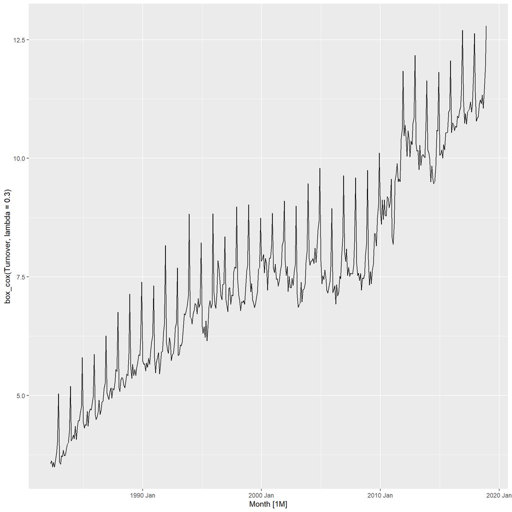

```r
myseries %>%
          autoplot(box_cox(Turnover, lambda = 0.3))
```

## Exercise 5

For the following series, find an appropriate Box-Cox transformation in order to stabilise the variance. Tobacco from aus_production, Economy class passengers between Melbourne and Sydney from ansett, and Pedestrian counts at Southern Cross Station from pedestrian.

[figure not shown]

```r
lambda_tobacco <- aus_production %>%
                   features(Tobacco, features = guerrero) %>%
                   pull(lambda_guerrero)
aus_production %>%
  autoplot(box_cox(Tobacco, lambda_tobacco)) +
  labs(y = "",
       title = latex2exp::TeX(paste0(
         "Transformed gas production with $\\lambda$ = ",
         round(lambda_tobacco,2))))
```

## Exercise 7

Consider the last five years of the Gas data from aus_production.

gas <- tail(aus_production, 5*4) %>% select(Gas) Plot the time series. Can you identify seasonal fluctuations and/or a trend-cycle? Use classical_decomposition with type=multiplicative to calculate the trend-cycle and seasonal indices. Do the results support the graphical interpretation from part a? Compute and plot the seasonally adjusted data. Change one observation to be an outlier (e.g., add 300 to one observation), and recompute the seasonally adjusted data. What is the effect of the outlier? Does it make any difference if the outlier is near the end rather than in the middle of the time series?

```r
require(graphics)
print("a-Plot the time series. Can you identify seasonal fluctuations and/or a trend-cycle? The trend is upward each season")
```

```
## [1] "a-Plot the time series. Can you identify seasonal fluctuations and/or a trend-cycle? The trend is upward each season"
```

```
## Plot variable not specified, automatically selected `.vars = Gas`
```

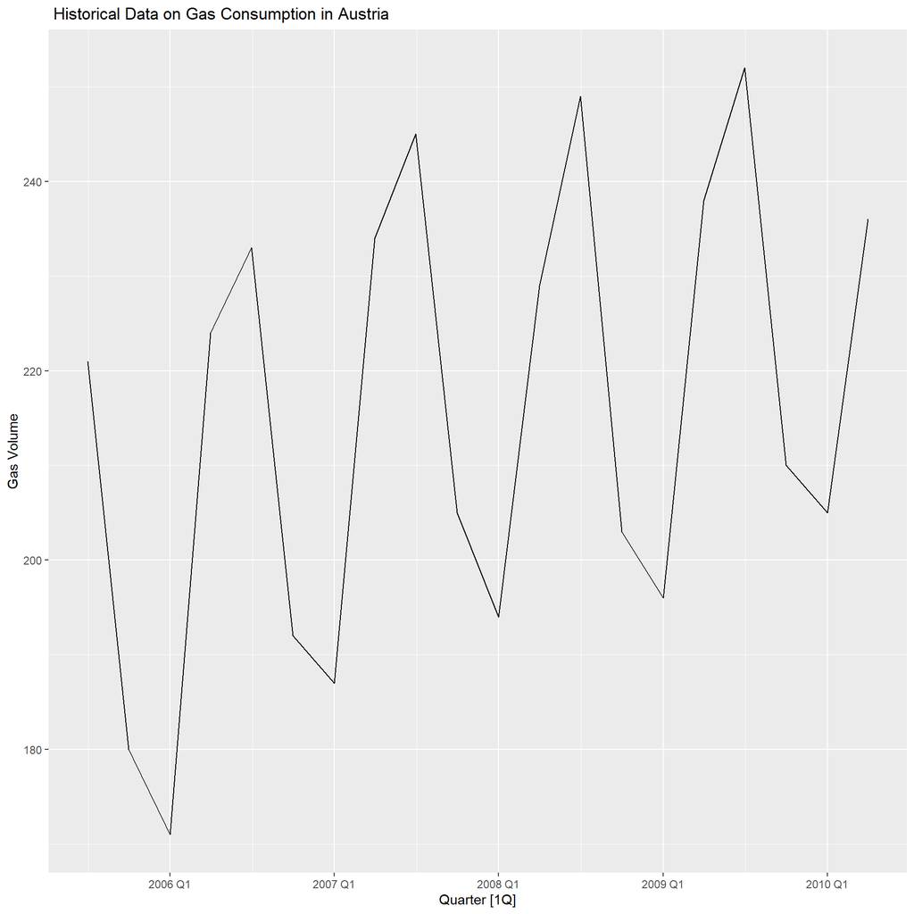

```r
gas <- tail(aus_production, 5*4) %>%
  dplyr::select(Gas)
gas %>%
  autoplot()+labs(title = " Historical Data on Gas Consumption in Austria  ", y = "Gas Volume" )
```

```r
print("Use classical_decomposition with type=multiplicative to calculate the trend-cycle and seasonal indices.")
```

```
## [1] "Use classical_decomposition with type=multiplicative to calculate the trend-cycle and seasonal indices."
```

```r
gas1a <- as_tsibble (gas) %>%
    model(classical_decomposition(type = 'multiplicative'))%>%
    components()%>%
    autoplot ()+labs(title = " Historical Data on Gas Consumption in Austria  ", y = "Gas Volume" )
```

```
## Model not specified, defaulting to automatic modelling of the `Gas` variable.
## Override this using the model formula.
```

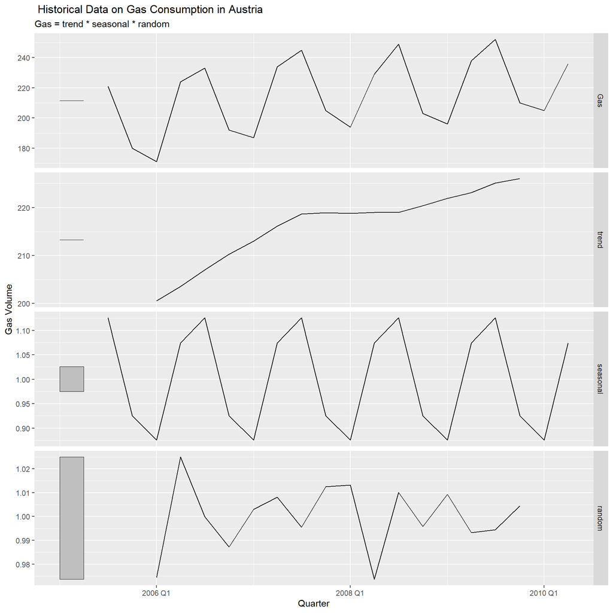

```r
gas1a
```

```r
print("Do the results support the graphical interpretation from part a? yes, it does.")
```

```
## [1] "Do the results support the graphical interpretation from part a? yes, it does."
```

```r
print("Compute and plot the seasonally adjusted data.n\ The red line is the adjusted data")
```

```
## [1] "Compute and plot the seasonally adjusted data.n The red line is the adjusted data"
```

```
## Model not specified, defaulting to automatic modelling of the `Gas` variable. Override this using the model formula.
## Plot variable not specified, automatically selected `.vars = Gas`
```

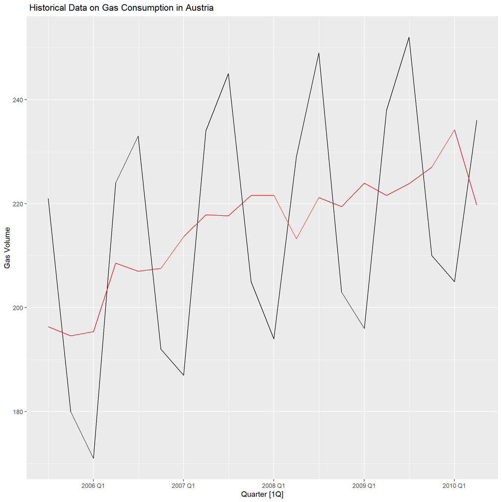

```r
as_tsibble(gas) %>%
     model(classical_decomposition(type ="multiplicative") )%>%
     components() %>%
     as_tsibble() %>%
     autoplot() + geom_line(aes(y=season_adjust), colour = "red") +labs(title = " Historical Data on Gas Consumption in Austria  ", y = "Gas Volume" )
```

```r
print("Change one observation to be an outlier (e.g., add 300 to one observation), and recompute the seasonally adjusted data. What is the effect of the outlier?")
```

```
## [1] "Change one observation to be an outlier (e.g., add 300 to one observation), and recompute the seasonally adjusted data. What is the effect of the outlier?"
```

```
## Model not specified, defaulting to automatic modelling of the `Gas` variable. Override this using the model formula.
## Plot variable not specified, automatically selected `.vars = Gas`
```

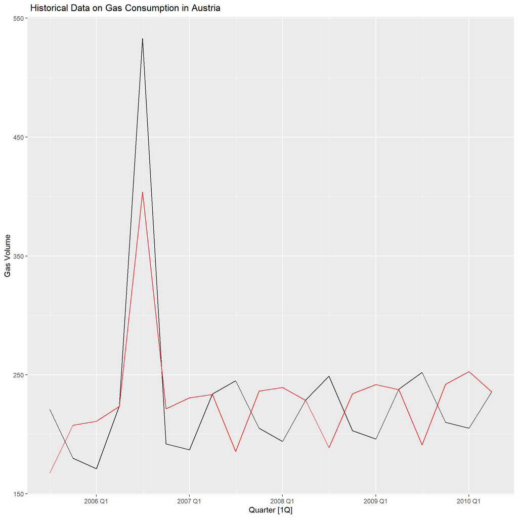

```r
gas$Gas[5]<-gas$Gas[5]+300
as_tsibble(gas) %>%
                model(classical_decomposition(type ="multiplicative") )%>%
                components() %>%
                as_tsibble() %>%
                autoplot() +geom_line(aes(y=season_adjust), colour = "red")+labs(title = " Historical Data on Gas Consumption in Austria  ", y = "Gas Volume" )
```

```r
print("Does it make any difference if the outlier is near the end rather than in the middle of the time series?")
```

```
## [1] "Does it make any difference if the outlier is near the end rather than in the middle of the time series?"
```

```
## Model not specified, defaulting to automatic modelling of the `Gas` variable. Override this using the model formula.
## Plot variable not specified, automatically selected `.vars = Gas`
```

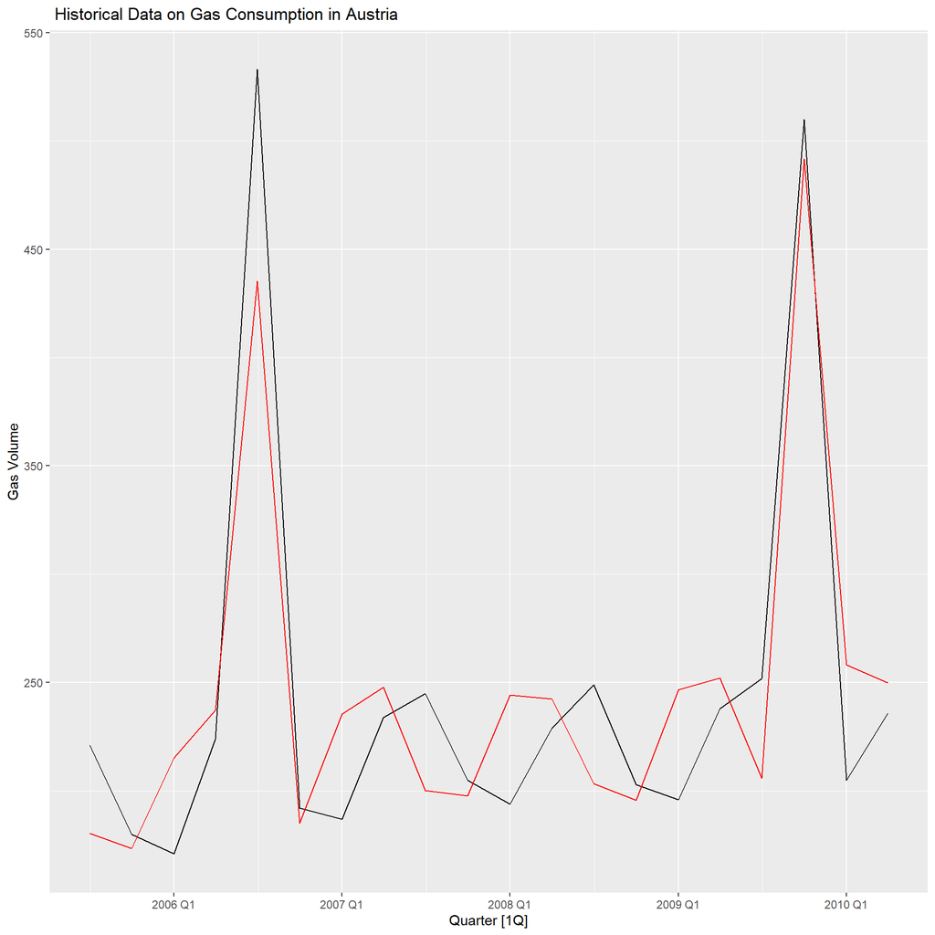

```r
gas$Gas[18]<-gas$Gas[18]+300
as_tsibble(gas) %>%
                model(classical_decomposition(type ="multiplicative") )%>%
                components() %>%
                as_tsibble() %>%
                autoplot() +geom_line(aes(y=season_adjust), colour = "red")+labs(title = " Historical Data on Gas Consumption in Austria  ", y = "Gas Volume" )
```

```r
print("Does it make any difference if the outlier is near the end rather than in the middle of the time series? Yes. The outliers effect depends on where it is located")
```

```
## [1] "Does it make any difference if the outlier is near the end rather than in the middle of the time series? Yes. The outliers effect depends on where it is located"
```

## Exercise 8

Recall your retail time series data (from Exercise 8 in Section 2.10). Decompose the series using X-11. Does it reveal any outliers, or unusual features that you had not noticed previously?

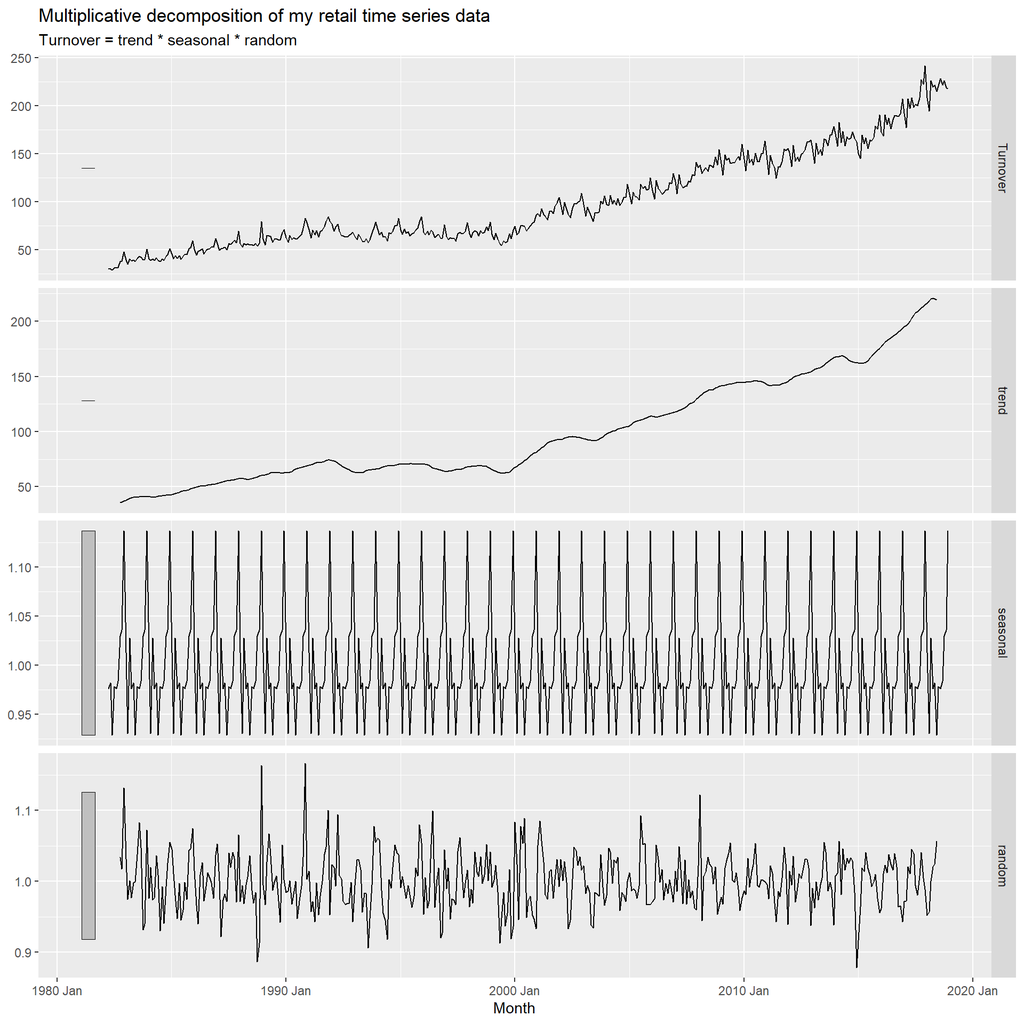

```r
myseries <- aus_retail %>%
  filter(`Series ID` == sample(aus_retail$`Series ID`,1))

myseries %>%
  model(classical_decomposition(Turnover,type = "multiplicative")) %>%
  components() %>%
  autoplot() +
  ggtitle("Multiplicative decomposition of my retail time series data")
```

## Exercise 9

Figures 3.19 and 3.20 show the result of decomposing the number of persons in the civilian labour force in Australia each month from February 1978 to August 1995.